# Business Confidence In Japan

アセット･マネジメント･コンサルティング株式会社 http://am-consulting.co.jp

2017-06-28 22:15:31

- アセット･マネジメント･コンサルティング株式会社 http://am-consulting.co.jp
- SaECaNet http://saecanet.com/
- Olive http://olive.saecanet.com/
- twitter https://twitter.com/AMC2_Japan
- 本ページへのリンクを共有:[Tweet](https://twitter.com/share)
- タイトル : 中小企業景況調査:2017年4~6月期
- データ出所 : 中小企業庁
- Source http://www.chusho.meti.go.jp/koukai/chousa/keikyo/

#### 中小企業景況調査-地域:全国-規模:全体-項目:業況判断-項目内容:前年同期比

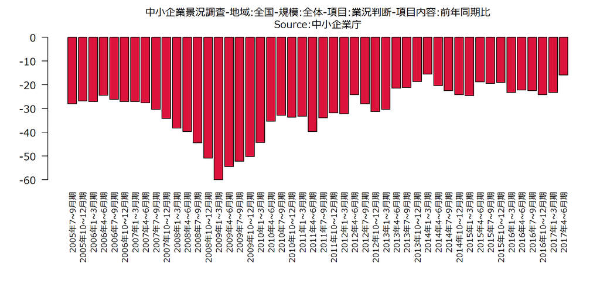

| Item | 2016年4~6月期 | 2016年7~9月期 | 2016年10~12月期 | 2017年1~3月期 | 2017年4~6月期 |
| --- | --- | --- | --- | --- | --- |
| 全産業:好転 | 11.2 | 10.8 | 10 | 10.6 | 13.2 |
| 全産業:不変 | 55.4 | 56 | 55.8 | 55.6 | 57.7 |
| 全産業:悪化 | 33.4 | 33.2 | 34.2 | 33.8 | 29.1 |
| 全産業:DI | -22.2 | -22.4 | -24.2 | -23.2 | -15.9 |
| 全産業:製造業:好転 | 13.4 | 12.6 | 12.5 | 13.3 | 16.6 |
| 全産業:製造業:不変 | 52.8 | 53.4 | 54.2 | 55.1 | 55.1 |
| 全産業:製造業:悪化 | 33.8 | 34 | 33.3 | 31.6 | 28.3 |
| 全産業:製造業:DI | -20.4 | -21.4 | -20.8 | -18.3 | -11.7 |
| 全産業:非製造業:好転 | 10.5 | 10.1 | 9.2 | 9.7 | 12 |
| 全産業:非製造業:不変 | 56.2 | 56.9 | 56.4 | 55.8 | 58.7 |
| 全産業:非製造業:悪化 | 33.3 | 33 | 34.4 | 34.5 | 29.3 |
| 全産業:非製造業:DI | -22.8 | -22.9 | -25.2 | -24.8 | -17.3 |
| 全産業:非製造業:建設業:好転 | 12.2 | 12.2 | 11.6 | 12.8 | 14.6 |
| 全産業:非製造業:建設業:不変 | 61 | 62 | 64.1 | 62.1 | 62.6 |
| 全産業:非製造業:建設業:悪化 | 26.8 | 25.8 | 24.3 | 25.1 | 22.8 |
| 全産業:非製造業:建設業:DI | -14.6 | -13.6 | -12.7 | -12.3 | -8.2 |
| 全産業:非製造業:非製造業(除く建設業):好転 | 10.2 | 9.7 | 8.7 | 9 | 11.5 |
| 全産業:非製造業:非製造業(除く建設業):不変 | 55.2 | 55.9 | 54.8 | 54.6 | 57.9 |
| 全産業:非製造業:非製造業(除く建設業):悪化 | 34.6 | 34.4 | 36.5 | 36.4 | 30.6 |
| 全産業:非製造業:非製造業(除く建設業):DI | -24.4 | -24.7 | -27.8 | -27.4 | -19.1 |
| 全産業:非製造業:非製造業(除く建設業):卸売業:好転 | 12.8 | 11.9 | 12 | 12.1 | 13.8 |
| 全産業:非製造業:非製造業(除く建設業):卸売業:不変 | 53 | 55.9 | 52.8 | 56.1 | 56.8 |
| 全産業:非製造業:非製造業(除く建設業):卸売業:悪化 | 34.2 | 32.2 | 35.2 | 31.8 | 29.4 |
| 全産業:非製造業:非製造業(除く建設業):卸売業:DI | -21.4 | -20.3 | -23.2 | -19.7 | -15.6 |
| 全産業:非製造業:非製造業(除く建設業):小売業:好転 | 8 | 7.4 | 6.3 | 6.3 | 8.7 |
| 全産業:非製造業:非製造業(除く建設業):小売業:不変 | 50.4 | 50.9 | 50.9 | 50 | 53.9 |
| 全産業:非製造業:非製造業(除く建設業):小売業:悪化 | 41.6 | 41.7 | 42.8 | 43.7 | 37.4 |
| 全産業:非製造業:非製造業(除く建設業):小売業:DI | -33.6 | -34.3 | -36.5 | -37.4 | -28.7 |
| 全産業:非製造業:非製造業(除く建設業):サービス業:好転 | 11.4 | 11 | 9.8 | 10.4 | 13.2 |
| 全産業:非製造業:非製造業(除く建設業):サービス業:不変 | 59.3 | 59.7 | 58.3 | 57.9 | 61.1 |
| 全産業:非製造業:非製造業(除く建設業):サービス業:悪化 | 29.3 | 29.3 | 31.9 | 31.7 | 25.7 |
| 全産業:非製造業:非製造業(除く建設業):サービス業:DI | -17.9 | -18.3 | -22.1 | -21.3 | -12.5 |

#### 中小企業景況調査-地域:全国-規模:全体-項目:業況判断-項目内容:前期比(原数値)

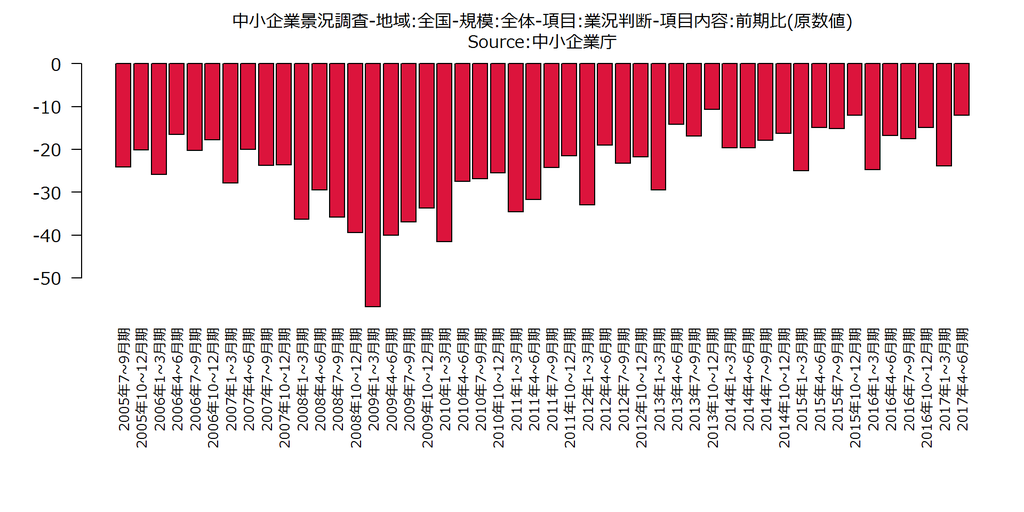

| Item | 2016年4~6月期 | 2016年7~9月期 | 2016年10~12月期 | 2017年1~3月期 | 2017年4~6月期 |
| --- | --- | --- | --- | --- | --- |
| 全産業:好転 | 11.8 | 11 | 12 | 8.6 | 12.8 |
| 全産業:不変 | 59.6 | 60.5 | 61.1 | 58.9 | 62.3 |
| 全産業:悪化 | 28.6 | 28.5 | 26.9 | 32.5 | 24.9 |
| 全産業:DI | -16.8 | -17.5 | -14.9 | -23.9 | -12.1 |
| 全産業:製造業:好転 | 13 | 11.9 | 14.7 | 10.8 | 14.5 |
| 全産業:製造業:不変 | 58.5 | 59.9 | 60.6 | 59.4 | 61.3 |
| 全産業:製造業:悪化 | 28.5 | 28.2 | 24.7 | 29.8 | 24.2 |
| 全産業:製造業:DI | -15.5 | -16.3 | -10 | -19 | -9.7 |
| 全産業:非製造業:好転 | 11.3 | 10.7 | 11.2 | 7.9 | 12.3 |
| 全産業:非製造業:不変 | 60.1 | 60.7 | 61.2 | 58.7 | 62.5 |
| 全産業:非製造業:悪化 | 28.6 | 28.6 | 27.6 | 33.4 | 25.2 |
| 全産業:非製造業:DI | -17.3 | -17.9 | -16.4 | -25.5 | -12.9 |
| 全産業:非製造業:建設業:好転 | 11.8 | 13.5 | 12.5 | 11.2 | 12.6 |
| 全産業:非製造業:建設業:不変 | 63.1 | 66.1 | 67.1 | 65.9 | 66.4 |
| 全産業:非製造業:建設業:悪化 | 25.1 | 20.4 | 20.4 | 22.9 | 21 |
| 全産業:非製造業:建設業:DI | -13.3 | -6.9 | -7.9 | -11.7 | -8.4 |
| 全産業:非製造業:非製造業(除く建設業):好転 | 11.2 | 10.1 | 10.9 | 7.2 | 12.2 |
| 全産業:非製造業:非製造業(除く建設業):不変 | 59.5 | 59.6 | 60 | 57.2 | 61.8 |
| 全産業:非製造業:非製造業(除く建設業):悪化 | 29.3 | 30.3 | 29.1 | 35.6 | 26 |
| 全産業:非製造業:非製造業(除く建設業):DI | -18.1 | -20.2 | -18.2 | -28.4 | -13.8 |
| 全産業:非製造業:非製造業(除く建設業):卸売業:好転 | 12.3 | 10.9 | 13.4 | 10.1 | 13.5 |
| 全産業:非製造業:非製造業(除く建設業):卸売業:不変 | 58.4 | 59.5 | 61.7 | 57.3 | 61 |
| 全産業:非製造業:非製造業(除く建設業):卸売業:悪化 | 29.3 | 29.6 | 24.9 | 32.6 | 25.5 |
| 全産業:非製造業:非製造業(除く建設業):卸売業:DI | -17 | -18.7 | -11.5 | -22.5 | -12 |
| 全産業:非製造業:非製造業(除く建設業):小売業:好転 | 9.9 | 8.6 | 9.7 | 5.5 | 9.8 |
| 全産業:非製造業:非製造業(除く建設業):小売業:不変 | 55.2 | 55.2 | 56.5 | 51.6 | 58.7 |
| 全産業:非製造業:非製造業(除く建設業):小売業:悪化 | 34.9 | 36.2 | 33.8 | 42.9 | 31.5 |
| 全産業:非製造業:非製造業(除く建設業):小売業:DI | -25 | -27.6 | -24.1 | -37.4 | -21.7 |
| 全産業:非製造業:非製造業(除く建設業):サービス業:好転 | 12.1 | 11 | 11.3 | 8 | 13.8 |
| 全産業:非製造業:非製造業(除く建設業):サービス業:不変 | 62.9 | 63 | 62.4 | 61.3 | 64.2 |
| 全産業:非製造業:非製造業(除く建設業):サービス業:悪化 | 25 | 26 | 26.3 | 30.7 | 22 |
| 全産業:非製造業:非製造業(除く建設業):サービス業:DI | -12.9 | -15 | -15 | -22.7 | -8.2 |

#### 中小企業景況調査-地域:全国-規模:全体-項目:業況判断DI-項目内容:前期比(季節調整値)

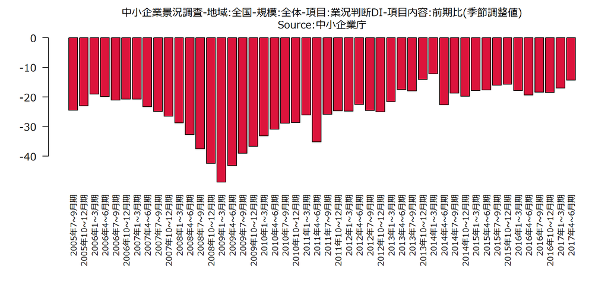

| Item | 2016年4~6月期 | 2016年7~9月期 | 2016年10~12月期 | 2017年1~3月期 | 2017年4~6月期 |
| --- | --- | --- | --- | --- | --- |
| 全産業 | -19.3 | -18.4 | -18.5 | -17 | -14.3 |
| 製造業 | -16.7 | -15.9 | -15.3 | -13 | -10.6 |
| 非製造業 | -20.2 | -19.2 | -19.5 | -18.4 | -15.5 |
| 建設業 | -11.1 | -9.3 | -10.9 | -8.6 | -6.2 |
| 非製造業(除く建設) | -21.9 | -21.4 | -21.2 | -20.5 | -17.4 |
| 卸売業 | -18.4 | -17.5 | -18.1 | -15.9 | -13.1 |
| 小売業 | -28.8 | -28.5 | -28.6 | -28.2 | -25.4 |
| サービス業 | -16.8 | -16.7 | -16.3 | -15.8 | -12 |

#### 中小企業景況調査-地域:全国-規模:全体-項目:業況判断-項目内容:今期の水準

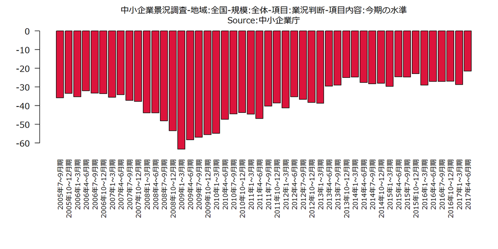

| Item | 2016年4~6月期 | 2016年7~9月期 | 2016年10~12月期 | 2017年1~3月期 | 2017年4~6月期 |
| --- | --- | --- | --- | --- | --- |
| 全産業:好転 | 10.6 | 10.7 | 10.3 | 10.2 | 12.3 |
| 全産業:不変 | 51.8 | 51.6 | 52.5 | 50.9 | 53.9 |
| 全産業:悪化 | 37.6 | 37.7 | 37.2 | 38.9 | 33.8 |
| 全産業:DI | -27 | -27 | -26.9 | -28.7 | -21.5 |
| 全産業:製造業:好転 | 11.9 | 11.1 | 11.9 | 12.5 | 14 |
| 全産業:製造業:不変 | 50.8 | 50.2 | 51.6 | 50.4 | 53.3 |
| 全産業:製造業:悪化 | 37.3 | 38.7 | 36.5 | 37.1 | 32.7 |
| 全産業:製造業:DI | -25.4 | -27.6 | -24.6 | -24.6 | -18.7 |
| 全産業:非製造業:好転 | 10.2 | 10.6 | 9.8 | 9.5 | 11.7 |
| 全産業:非製造業:不変 | 52 | 52 | 52.7 | 51 | 54.2 |
| 全産業:非製造業:悪化 | 37.8 | 37.4 | 37.5 | 39.5 | 34.1 |
| 全産業:非製造業:DI | -27.6 | -26.8 | -27.7 | -30 | -22.4 |
| 全産業:非製造業:建設業:好転 | 14 | 15 | 14.2 | 14.1 | 16.3 |
| 全産業:非製造業:建設業:不変 | 56.4 | 57.3 | 59.3 | 58.4 | 57.6 |
| 全産業:非製造業:建設業:悪化 | 29.6 | 27.7 | 26.5 | 27.5 | 26.1 |
| 全産業:非製造業:建設業:DI | -15.6 | -12.7 | -12.3 | -13.4 | -9.8 |
| 全産業:非製造業:非製造業(除く建設業):好転 | 9.5 | 9.7 | 9 | 8.5 | 10.8 |
| 全産業:非製造業:非製造業(除く建設業):不変 | 51.1 | 50.9 | 51.3 | 49.6 | 53.5 |
| 全産業:非製造業:非製造業(除く建設業):悪化 | 39.4 | 39.4 | 39.7 | 41.9 | 35.7 |
| 全産業:非製造業:非製造業(除く建設業):DI | -29.9 | -29.7 | -30.7 | -33.4 | -24.9 |
| 全産業:非製造業:非製造業(除く建設業):卸売業:好転 | 9.3 | 10.1 | 11.3 | 9.3 | 11.2 |
| 全産業:非製造業:非製造業(除く建設業):卸売業:不変 | 49.9 | 48.4 | 51.3 | 50.5 | 52.1 |
| 全産業:非製造業:非製造業(除く建設業):卸売業:悪化 | 40.8 | 41.5 | 37.4 | 40.2 | 36.7 |
| 全産業:非製造業:非製造業(除く建設業):卸売業:DI | -31.5 | -31.4 | -26.1 | -30.9 | -25.5 |
| 全産業:非製造業:非製造業(除く建設業):小売業:好転 | 7 | 6.9 | 6.2 | 6.3 | 7.6 |
| 全産業:非製造業:非製造業(除く建設業):小売業:不変 | 45.4 | 45.9 | 46.1 | 43.3 | 47.8 |
| 全産業:非製造業:非製造業(除く建設業):小売業:悪化 | 47.6 | 47.2 | 47.7 | 50.4 | 44.6 |
| 全産業:非製造業:非製造業(除く建設業):小売業:DI | -40.6 | -40.3 | -41.5 | -44.1 | -37 |
| 全産業:非製造業:非製造業(除く建設業):サービス業:好転 | 11.4 | 11.9 | 10.6 | 10.1 | 13.2 |
| 全産業:非製造業:非製造業(除く建設業):サービス業:不変 | 55.8 | 55.1 | 55.4 | 54.2 | 58.1 |
| 全産業:非製造業:非製造業(除く建設業):サービス業:悪化 | 32.8 | 33 | 34 | 35.7 | 28.7 |
| 全産業:非製造業:非製造業(除く建設業):サービス業:DI | -21.4 | -21.1 | -23.4 | -25.6 | -15.5 |

#### 中小企業景況調査-地域:全国-規模:全体-項目:売上(加工)額-項目内容:前年同期比

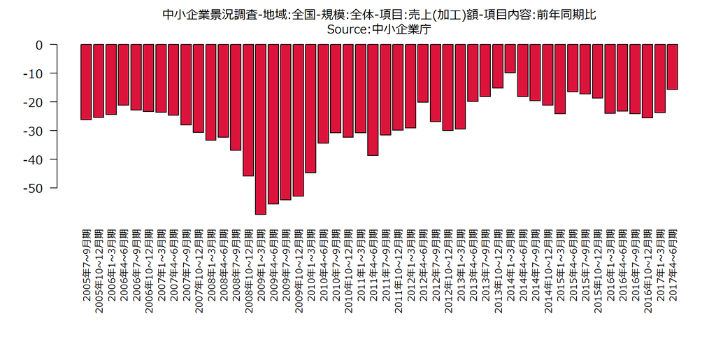

| Item | 2016年4~6月期 | 2016年7~9月期 | 2016年10~12月期 | 2017年1~3月期 | 2017年4~6月期 |
| --- | --- | --- | --- | --- | --- |
| 全産業:好転 | 18.8 | 17.9 | 16.7 | 18 | 21.3 |
| 全産業:不変 | 39.2 | 40 | 41 | 40.3 | 41.7 |
| 全産業:悪化 | 42 | 42.1 | 42.3 | 41.7 | 37 |
| 全産業:DI | -23.2 | -24.2 | -25.6 | -23.7 | -15.7 |
| 全産業:製造業:好転 | 20.5 | 18.8 | 17.4 | 19.9 | 23.9 |
| 全産業:製造業:不変 | 39.8 | 39.7 | 41.5 | 41 | 41.5 |
| 全産業:製造業:悪化 | 39.7 | 41.5 | 41.1 | 39.1 | 34.6 |
| 全産業:製造業:DI | -19.2 | -22.7 | -23.7 | -19.2 | -10.7 |
| 全産業:非製造業:好転 | 18.2 | 17.6 | 16.5 | 17.3 | 20.5 |
| 全産業:非製造業:不変 | 39 | 40.1 | 40.9 | 40.1 | 41.7 |
| 全産業:非製造業:悪化 | 42.8 | 42.3 | 42.6 | 42.6 | 37.8 |
| 全産業:非製造業:DI | -24.6 | -24.7 | -26.1 | -25.3 | -17.3 |
| 全産業:非製造業:建設業:好転 | 20.3 | 21.4 | 19.7 | 22.2 | 23.5 |
| 全産業:非製造業:建設業:不変 | 40.3 | 41.3 | 44.5 | 41.7 | 43.1 |
| 全産業:非製造業:建設業:悪化 | 39.4 | 37.3 | 35.8 | 36.1 | 33.4 |
| 全産業:非製造業:建設業:DI | -19.1 | -15.9 | -16.1 | -13.9 | -9.9 |
| 全産業:非製造業:非製造業(除く建設業):好転 | 17.8 | 16.8 | 15.8 | 16.4 | 19.8 |
| 全産業:非製造業:非製造業(除く建設業):不変 | 38.8 | 39.9 | 40.2 | 39.8 | 41.5 |
| 全産業:非製造業:非製造業(除く建設業):悪化 | 43.4 | 43.3 | 44 | 43.8 | 38.7 |
| 全産業:非製造業:非製造業(除く建設業):DI | -25.6 | -26.5 | -28.2 | -27.4 | -18.9 |
| 全産業:非製造業:非製造業(除く建設業):卸売業:好転 | 21.4 | 18.8 | 19.1 | 18.1 | 21.9 |
| 全産業:非製造業:非製造業(除く建設業):卸売業:不変 | 38 | 39.5 | 39.6 | 39.8 | 39.6 |
| 全産業:非製造業:非製造業(除く建設業):卸売業:悪化 | 40.6 | 41.7 | 41.3 | 42.1 | 38.5 |
| 全産業:非製造業:非製造業(除く建設業):卸売業:DI | -19.2 | -22.9 | -22.2 | -24 | -16.6 |
| 全産業:非製造業:非製造業(除く建設業):小売業:好転 | 14.8 | 13.4 | 12.8 | 14.1 | 16.4 |
| 全産業:非製造業:非製造業(除く建設業):小売業:不変 | 34.9 | 35.7 | 36.4 | 35.6 | 37.9 |
| 全産業:非製造業:非製造業(除く建設業):小売業:悪化 | 50.3 | 50.9 | 50.8 | 50.3 | 45.7 |
| 全産業:非製造業:非製造業(除く建設業):小売業:DI | -35.5 | -37.5 | -38 | -36.2 | -29.3 |
| 全産業:非製造業:非製造業(除く建設業):サービス業:好転 | 19.5 | 19 | 17.5 | 17.7 | 22.1 |
| 全産業:非製造業:非製造業(除く建設業):サービス業:不変 | 41.9 | 43.2 | 43.1 | 43 | 44.6 |
| 全産業:非製造業:非製造業(除く建設業):サービス業:悪化 | 38.6 | 37.8 | 39.4 | 39.3 | 33.3 |
| 全産業:非製造業:非製造業(除く建設業):サービス業:DI | -19.1 | -18.8 | -21.9 | -21.6 | -11.2 |

#### 中小企業景況調査-地域:全国-規模:全体-項目:売上(加工)額-項目内容:前期比(原数値)

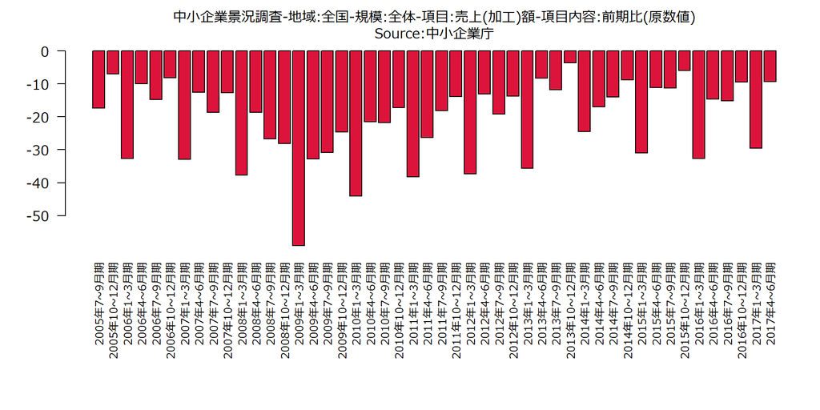

| Item | 2016年4~6月期 | 2016年7~9月期 | 2016年10~12月期 | 2017年1~3月期 | 2017年4~6月期 |
| --- | --- | --- | --- | --- | --- |
| 全産業:好転 | 22.8 | 21.7 | 23.8 | 15.9 | 24.7 |
| 全産業:不変 | 39.8 | 41.4 | 43 | 38.6 | 41.3 |
| 全産業:悪化 | 37.4 | 36.9 | 33.2 | 45.5 | 34 |
| 全産業:DI | -14.6 | -15.2 | -9.4 | -29.6 | -9.3 |
| 全産業:製造業:好転 | 22.9 | 20.7 | 26 | 17.1 | 25.1 |
| 全産業:製造業:不変 | 40.7 | 42.8 | 44 | 40.8 | 42.8 |
| 全産業:製造業:悪化 | 36.4 | 36.5 | 30 | 42.1 | 32.1 |
| 全産業:製造業:DI | -13.5 | -15.8 | -4 | -25 | -7 |
| 全産業:非製造業:好転 | 22.7 | 22 | 23.1 | 15.5 | 24.6 |
| 全産業:非製造業:不変 | 39.6 | 41 | 42.6 | 37.9 | 40.7 |
| 全産業:非製造業:悪化 | 37.7 | 37 | 34.3 | 46.6 | 34.7 |
| 全産業:非製造業:DI | -15 | -15 | -11.2 | -31.1 | -10.1 |
| 全産業:非製造業:建設業:好転 | 20 | 24.1 | 24 | 22.3 | 21.5 |
| 全産業:非製造業:建設業:不変 | 41 | 45.2 | 47 | 42.9 | 41.7 |
| 全産業:非製造業:建設業:悪化 | 39 | 30.7 | 29 | 34.8 | 36.8 |
| 全産業:非製造業:建設業:DI | -19 | -6.6 | -5 | -12.5 | -15.3 |
| 全産業:非製造業:非製造業(除く建設業):好転 | 23.2 | 21.6 | 22.9 | 14.1 | 25.2 |
| 全産業:非製造業:非製造業(除く建設業):不変 | 39.4 | 40.1 | 41.8 | 36.8 | 40.6 |
| 全産業:非製造業:非製造業(除く建設業):悪化 | 37.4 | 38.3 | 35.3 | 49.1 | 34.2 |
| 全産業:非製造業:非製造業(除く建設業):DI | -14.2 | -16.7 | -12.4 | -35 | -9 |
| 全産業:非製造業:非製造業(除く建設業):卸売業:好転 | 25.3 | 21.3 | 26.9 | 14.7 | 27.4 |
| 全産業:非製造業:非製造業(除く建設業):卸売業:不変 | 38.3 | 41.5 | 42.6 | 37.1 | 38.3 |
| 全産業:非製造業:非製造業(除く建設業):卸売業:悪化 | 36.4 | 37.2 | 30.5 | 48.2 | 34.3 |
| 全産業:非製造業:非製造業(除く建設業):卸売業:DI | -11.1 | -15.9 | -3.6 | -33.5 | -6.9 |
| 全産業:非製造業:非製造業(除く建設業):小売業:好転 | 22 | 20.3 | 23.7 | 12.5 | 23.5 |
| 全産業:非製造業:非製造業(除く建設業):小売業:不変 | 36.4 | 34.9 | 36.7 | 31.8 | 36.9 |
| 全産業:非製造業:非製造業(除く建設業):小売業:悪化 | 41.6 | 44.8 | 39.6 | 55.7 | 39.6 |
| 全産業:非製造業:非製造業(除く建設業):小売業:DI | -19.6 | -24.5 | -15.9 | -43.2 | -16.1 |
| 全産業:非製造業:非製造業(除く建設業):サービス業:好転 | 23.8 | 22.6 | 21.5 | 15.2 | 26.1 |
| 全産業:非製造業:非製造業(除く建設業):サービス業:不変 | 41.8 | 43.9 | 45.5 | 40.7 | 43.8 |
| 全産業:非製造業:非製造業(除く建設業):サービス業:悪化 | 34.4 | 33.5 | 33 | 44.1 | 30.1 |
| 全産業:非製造業:非製造業(除く建設業):サービス業:DI | -10.6 | -10.9 | -11.5 | -28.9 | -4 |

#### 中小企業景況調査-地域:全国-規模:全体-項目:売上(加工)額DI-項目内容:前期比(季節調整値)

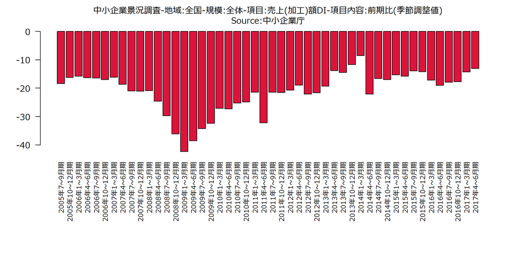

| Item | 2016年4~6月期 | 2016年7~9月期 | 2016年10~12月期 | 2017年1~3月期 | 2017年4~6月期 |
| --- | --- | --- | --- | --- | --- |
| 全産業 | -19 | -17.9 | -17.7 | -14.3 | -13.1 |
| 製造業 | -15.8 | -16.3 | -15.6 | -10.8 | -8.8 |
| 非製造業 | -20 | -18.4 | -18.4 | -15.6 | -14.6 |
| 建設業 | -12.9 | -11.6 | -12.1 | -6.6 | -8.8 |
| 非製造業(除く建設) | -21.3 | -19.9 | -19.6 | -17.5 | -15.6 |
| 卸売業 | -15.7 | -15.9 | -19.3 | -13.4 | -11.1 |
| 小売業 | -27.3 | -26.5 | -25.7 | -23.7 | -23.3 |
| サービス業 | -17.4 | -15.2 | -15.5 | -14 | -10.4 |

#### 中小企業景況調査-地域:全国-規模:全体-項目:経常利益-項目内容:前年同期比

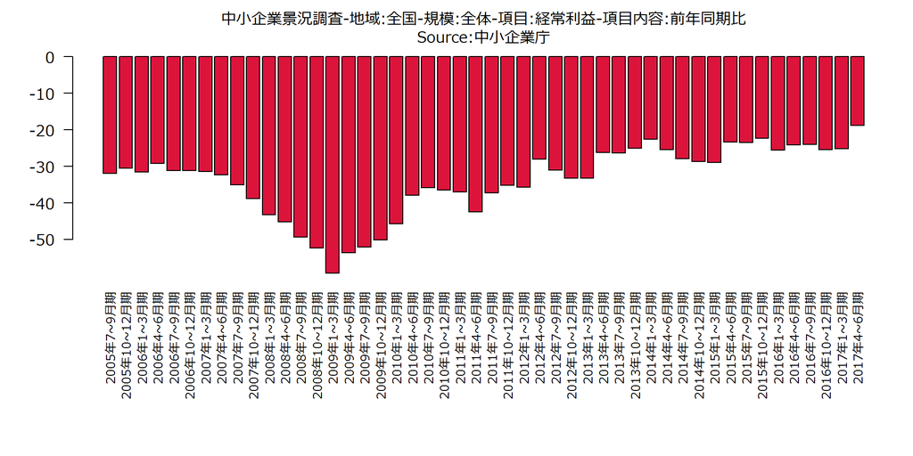

| Item | 2016年4~6月期 | 2016年7~9月期 | 2016年10~12月期 | 2017年1~3月期 | 2017年4~6月期 |
| --- | --- | --- | --- | --- | --- |
| 全産業:好転 | 10.7 | 10.4 | 9.8 | 9.7 | 11.7 |
| 全産業:不変 | 54.5 | 55.2 | 55 | 55.4 | 57.8 |
| 全産業:悪化 | 34.8 | 34.4 | 35.2 | 34.9 | 30.5 |
| 全産業:DI | -24.1 | -24 | -25.4 | -25.2 | -18.8 |
| 全産業:製造業:好転 | 13.2 | 12.5 | 11.7 | 12 | 14.5 |
| 全産業:製造業:不変 | 52.8 | 53 | 54.6 | 54.9 | 56.6 |
| 全産業:製造業:悪化 | 34 | 34.5 | 33.7 | 33.1 | 28.9 |
| 全産業:製造業:DI | -20.8 | -22 | -22 | -21.1 | -14.4 |
| 全産業:非製造業:好転 | 9.8 | 9.8 | 9.2 | 8.9 | 10.8 |
| 全産業:非製造業:不変 | 55.1 | 55.8 | 55.2 | 55.6 | 58.2 |
| 全産業:非製造業:悪化 | 35.1 | 34.4 | 35.6 | 35.5 | 31 |
| 全産業:非製造業:DI | -25.3 | -24.6 | -26.4 | -26.6 | -20.2 |
| 全産業:非製造業:建設業:好転 | 10.5 | 9.6 | 10.8 | 10 | 12 |
| 全産業:非製造業:建設業:不変 | 60.5 | 63.8 | 63.3 | 62.8 | 63.5 |
| 全産業:非製造業:建設業:悪化 | 29 | 26.6 | 25.9 | 27.2 | 24.5 |
| 全産業:非製造業:建設業:DI | -18.5 | -17 | -15.1 | -17.2 | -12.5 |
| 全産業:非製造業:非製造業(除く建設業):好転 | 9.7 | 9.8 | 8.8 | 8.7 | 10.5 |
| 全産業:非製造業:非製造業(除く建設業):不変 | 54 | 54.2 | 53.6 | 54.1 | 57.2 |
| 全産業:非製造業:非製造業(除く建設業):悪化 | 36.3 | 36 | 37.6 | 37.2 | 32.3 |
| 全産業:非製造業:非製造業(除く建設業):DI | -26.6 | -26.2 | -28.8 | -28.5 | -21.8 |
| 全産業:非製造業:非製造業(除く建設業):卸売業:好転 | 12.7 | 12.3 | 12.7 | 12.4 | 13.8 |
| 全産業:非製造業:非製造業(除く建設業):卸売業:不変 | 55.4 | 53.5 | 52.8 | 55.9 | 55.6 |
| 全産業:非製造業:非製造業(除く建設業):卸売業:悪化 | 31.9 | 34.2 | 34.5 | 31.7 | 30.6 |
| 全産業:非製造業:非製造業(除く建設業):卸売業:DI | -19.2 | -21.9 | -21.8 | -19.3 | -16.8 |
| 全産業:非製造業:非製造業(除く建設業):小売業:好転 | 7.5 | 7.3 | 6.9 | 6.4 | 7.8 |
| 全産業:非製造業:非製造業(除く建設業):小売業:不変 | 51 | 51.1 | 50.8 | 50.5 | 55.1 |
| 全産業:非製造業:非製造業(除く建設業):小売業:悪化 | 41.5 | 41.6 | 42.3 | 43.1 | 37.1 |
| 全産業:非製造業:非製造業(除く建設業):小売業:DI | -34 | -34.3 | -35.4 | -36.7 | -29.3 |
| 全産業:非製造業:非製造業(除く建設業):サービス業:好転 | 10.9 | 11.3 | 9.6 | 9.7 | 12 |
| 全産業:非製造業:非製造業(除く建設業):サービス業:不変 | 56 | 56.7 | 55.8 | 56.5 | 59 |
| 全産業:非製造業:非製造業(除く建設業):サービス業:悪化 | 33.1 | 32 | 34.6 | 33.8 | 29 |
| 全産業:非製造業:非製造業(除く建設業):サービス業:DI | -22.2 | -20.7 | -25 | -24.1 | -17 |

#### 中小企業景況調査-地域:全国-規模:全体-項目:資金繰り-項目内容:前年同期比

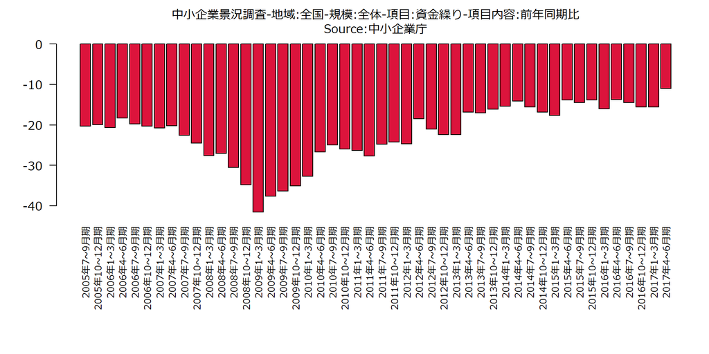

| Item | 2016年4~6月期 | 2016年7~9月期 | 2016年10~12月期 | 2017年1~3月期 | 2017年4~6月期 |
| --- | --- | --- | --- | --- | --- |
| 全産業:好転 | 6.5 | 6.1 | 5.6 | 5.6 | 7.2 |
| 全産業:不変 | 73.3 | 73.3 | 73.2 | 73.2 | 74.6 |
| 全産業:悪化 | 20.2 | 20.6 | 21.2 | 21.2 | 18.2 |
| 全産業:DI | -13.7 | -14.5 | -15.6 | -15.6 | -11 |
| 全産業:製造業:好転 | 6.9 | 6.3 | 5.8 | 6.3 | 8.4 |
| 全産業:製造業:不変 | 73.7 | 73.7 | 73.6 | 74.7 | 74.4 |
| 全産業:製造業:悪化 | 19.4 | 20 | 20.6 | 19 | 17.2 |
| 全産業:製造業:DI | -12.5 | -13.7 | -14.8 | -12.7 | -8.8 |
| 全産業:非製造業:好転 | 6.3 | 6.1 | 5.6 | 5.4 | 6.9 |
| 全産業:非製造業:不変 | 73.2 | 73.1 | 73 | 72.6 | 74.6 |
| 全産業:非製造業:悪化 | 20.5 | 20.8 | 21.4 | 22 | 18.5 |
| 全産業:非製造業:DI | -14.2 | -14.7 | -15.8 | -16.6 | -11.6 |
| 全産業:非製造業:建設業:好転 | 8.8 | 8.4 | 8.4 | 8.1 | 9.6 |
| 全産業:非製造業:建設業:不変 | 75.6 | 75.8 | 76.2 | 75.6 | 76.8 |
| 全産業:非製造業:建設業:悪化 | 15.6 | 15.8 | 15.4 | 16.3 | 13.6 |
| 全産業:非製造業:建設業:DI | -6.8 | -7.4 | -7 | -8.2 | -4 |
| 全産業:非製造業:非製造業(除く建設業):好転 | 5.8 | 5.6 | 5 | 4.8 | 6.3 |
| 全産業:非製造業:非製造業(除く建設業):不変 | 72.8 | 72.5 | 72.4 | 72.1 | 74.2 |
| 全産業:非製造業:非製造業(除く建設業):悪化 | 21.4 | 21.9 | 22.6 | 23.1 | 19.5 |
| 全産業:非製造業:非製造業(除く建設業):DI | -15.6 | -16.3 | -17.6 | -18.3 | -13.2 |
| 全産業:非製造業:非製造業(除く建設業):卸売業:好転 | 6.8 | 7.1 | 7.5 | 6.6 | 8.5 |
| 全産業:非製造業:非製造業(除く建設業):卸売業:不変 | 78.7 | 77.5 | 76.3 | 78.9 | 78.1 |
| 全産業:非製造業:非製造業(除く建設業):卸売業:悪化 | 14.5 | 15.4 | 16.2 | 14.5 | 13.4 |
| 全産業:非製造業:非製造業(除く建設業):卸売業:DI | -7.7 | -8.3 | -8.7 | -7.9 | -4.9 |
| 全産業:非製造業:非製造業(除く建設業):小売業:好転 | 4.5 | 4.1 | 3.2 | 3.4 | 4.5 |
| 全産業:非製造業:非製造業(除く建設業):小売業:不変 | 69.5 | 69.5 | 70.2 | 68.6 | 71.6 |
| 全産業:非製造業:非製造業(除く建設業):小売業:悪化 | 26 | 26.4 | 26.6 | 28 | 23.9 |
| 全産業:非製造業:非製造業(除く建設業):小売業:DI | -21.5 | -22.3 | -23.4 | -24.6 | -19.4 |
| 全産業:非製造業:非製造業(除く建設業):サービス業:好転 | 6.7 | 6.5 | 6 | 5.6 | 7.3 |
| 全産業:非製造業:非製造業(除く建設業):サービス業:不変 | 74 | 73.9 | 73.2 | 73.3 | 75.4 |
| 全産業:非製造業:非製造業(除く建設業):サービス業:悪化 | 19.3 | 19.6 | 20.8 | 21.1 | 17.3 |
| 全産業:非製造業:非製造業(除く建設業):サービス業:DI | -12.6 | -13.1 | -14.8 | -15.5 | -10 |

#### 中小企業景況調査-地域:全国-規模:全体-項目:資金繰り-項目内容:前期比(原数値)

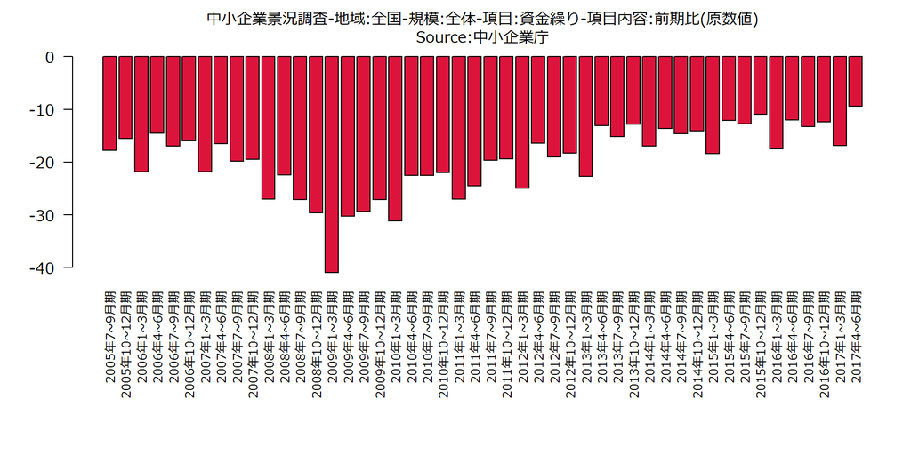

| Item | 2016年4~6月期 | 2016年7~9月期 | 2016年10~12月期 | 2017年1~3月期 | 2017年4~6月期 |
| --- | --- | --- | --- | --- | --- |
| 全産業:好転 | 6.5 | 5.8 | 6 | 4.8 | 7.1 |
| 全産業:不変 | 75 | 75.1 | 75.6 | 73.5 | 76.4 |
| 全産業:悪化 | 18.5 | 19.1 | 18.4 | 21.7 | 16.5 |
| 全産業:DI | -12 | -13.3 | -12.4 | -16.9 | -9.4 |
| 全産業:製造業:好転 | 6.2 | 5.4 | 6.3 | 5.2 | 6.8 |
| 全産業:製造業:不変 | 75.8 | 76.6 | 76.8 | 75.6 | 77.7 |
| 全産業:製造業:悪化 | 18 | 18 | 16.9 | 19.2 | 15.5 |
| 全産業:製造業:DI | -11.8 | -12.6 | -10.6 | -14 | -8.7 |
| 全産業:非製造業:好転 | 6.6 | 5.9 | 5.9 | 4.7 | 7.2 |
| 全産業:非製造業:不変 | 74.7 | 74.7 | 75.2 | 72.7 | 75.9 |
| 全産業:非製造業:悪化 | 18.7 | 19.4 | 18.9 | 22.6 | 16.9 |
| 全産業:非製造業:DI | -12.1 | -13.5 | -13 | -17.9 | -9.7 |
| 全産業:非製造業:建設業:好転 | 8.9 | 7.5 | 7.7 | 6.8 | 9.7 |
| 全産業:非製造業:建設業:不変 | 76 | 78.7 | 78.6 | 76.9 | 76.9 |
| 全産業:非製造業:建設業:悪化 | 15.1 | 13.8 | 13.7 | 16.3 | 13.4 |
| 全産業:非製造業:建設業:DI | -6.2 | -6.3 | -6 | -9.5 | -3.7 |
| 全産業:非製造業:非製造業(除く建設業):好転 | 6.1 | 5.6 | 5.6 | 4.2 | 6.7 |
| 全産業:非製造業:非製造業(除く建設業):不変 | 74.5 | 73.8 | 74.4 | 72 | 75.7 |
| 全産業:非製造業:非製造業(除く建設業):悪化 | 19.4 | 20.6 | 20 | 23.8 | 17.6 |
| 全産業:非製造業:非製造業(除く建設業):DI | -13.3 | -15 | -14.4 | -19.6 | -10.9 |
| 全産業:非製造業:非製造業(除く建設業):卸売業:好転 | 6.8 | 5.2 | 5.8 | 5.8 | 7.3 |
| 全産業:非製造業:非製造業(除く建設業):卸売業:不変 | 80.2 | 80.1 | 80.7 | 79.2 | 81.2 |
| 全産業:非製造業:非製造業(除く建設業):卸売業:悪化 | 13 | 14.7 | 13.5 | 15 | 11.5 |
| 全産業:非製造業:非製造業(除く建設業):卸売業:DI | -6.2 | -9.5 | -7.7 | -9.2 | -4.2 |
| 全産業:非製造業:非製造業(除く建設業):小売業:好転 | 5.2 | 4.5 | 4.9 | 3.3 | 5.4 |
| 全産業:非製造業:非製造業(除く建設業):小売業:不変 | 71.2 | 70.8 | 71.4 | 67.8 | 72.9 |
| 全産業:非製造業:非製造業(除く建設業):小売業:悪化 | 23.6 | 24.7 | 23.7 | 28.9 | 21.7 |
| 全産業:非製造業:非製造業(除く建設業):小売業:DI | -18.4 | -20.2 | -18.8 | -25.6 | -16.3 |
| 全産業:非製造業:非製造業(除く建設業):サービス業:好転 | 6.7 | 6.5 | 6 | 4.6 | 7.5 |
| 全産業:非製造業:非製造業(除く建設業):サービス業:不変 | 76 | 75 | 75.5 | 73.8 | 77 |
| 全産業:非製造業:非製造業(除く建設業):サービス業:悪化 | 17.3 | 18.5 | 18.5 | 21.6 | 15.5 |
| 全産業:非製造業:非製造業(除く建設業):サービス業:DI | -10.6 | -12 | -12.5 | -17 | -8 |

#### 中小企業景況調査-地域:全国-規模:全体-項目:資金繰りDI-項目内容:前期比(季節調整値)

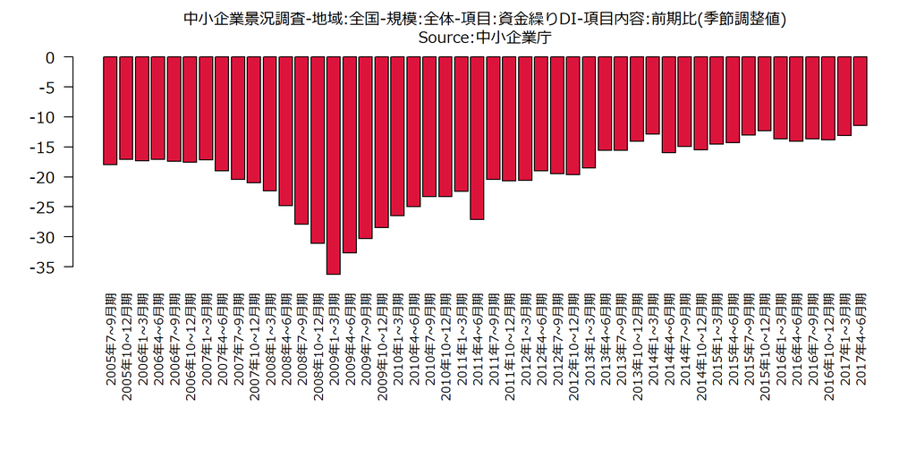

| Item | 2016年4~6月期 | 2016年7~9月期 | 2016年10~12月期 | 2017年1~3月期 | 2017年4~6月期 |
| --- | --- | --- | --- | --- | --- |
| 全産業 | -14.1 | -13.7 | -13.8 | -13.1 | -11.4 |
| 製造業 | -13.4 | -12.2 | -12 | -11.4 | -10 |
| 非製造業 | -14.3 | -14.1 | -14.4 | -13.7 | -11.8 |
| 建設業 | -7.3 | -6.8 | -7.1 | -6.9 | -4.9 |
| 非製造業(除く建設) | -15.6 | -15.7 | -15.9 | -15.1 | -13.1 |
| 卸売業 | -8.8 | -9 | -8.2 | -6.6 | -6.6 |
| 小売業 | -20.4 | -20.9 | -21.4 | -20.4 | -18.2 |
| サービス業 | -13.1 | -13.3 | -13.3 | -12.4 | -10.4 |

#### 中小企業景況調査-地域:全国-規模:全体-項目:長期資金借入難易度-項目内容:前期比(原数値)

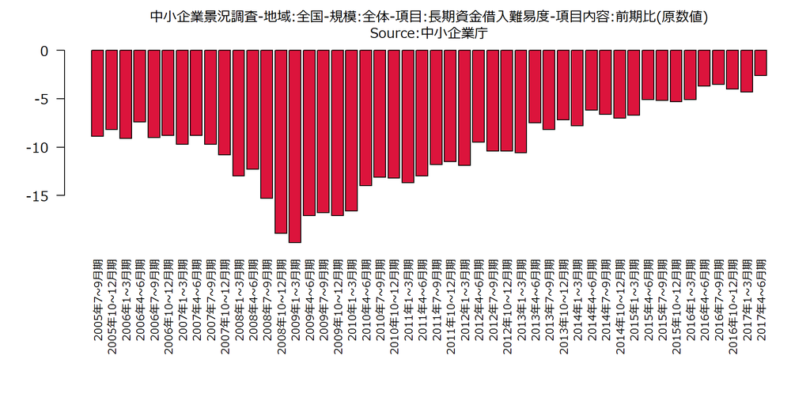

| Item | 2016年4~6月期 | 2016年7~9月期 | 2016年10~12月期 | 2017年1~3月期 | 2017年4~6月期 |
| --- | --- | --- | --- | --- | --- |
| 全産業:好転 | 7.3 | 7.4 | 6.9 | 6.8 | 7.4 |
| 全産業:不変 | 81.7 | 81.7 | 82.2 | 82.1 | 82.6 |
| 全産業:悪化 | 11 | 10.9 | 10.9 | 11.1 | 10 |
| 全産業:DI | -3.7 | -3.5 | -4 | -4.3 | -2.6 |
| 全産業:製造業:好転 | 7.9 | 8 | 7.3 | 7.4 | 7.8 |
| 全産業:製造業:不変 | 82.9 | 83.2 | 84.2 | 83.8 | 84.5 |
| 全産業:製造業:悪化 | 9.2 | 8.8 | 8.5 | 8.8 | 7.7 |
| 全産業:製造業:DI | -1.3 | -0.8 | -1.2 | -1.4 | 0.1 |
| 全産業:非製造業:好転 | 7.1 | 7.2 | 6.7 | 6.5 | 7.2 |
| 全産業:非製造業:不変 | 81.3 | 81.1 | 81.5 | 81.6 | 82 |
| 全産業:非製造業:悪化 | 11.6 | 11.7 | 11.8 | 11.9 | 10.8 |
| 全産業:非製造業:DI | -4.5 | -4.5 | -5.1 | -5.4 | -3.6 |
| 全産業:非製造業:建設業:好転 | 8.8 | 9.4 | 8.3 | 7.9 | 8.9 |
| 全産業:非製造業:建設業:不変 | 83.5 | 84 | 84.6 | 85.7 | 84.9 |
| 全産業:非製造業:建設業:悪化 | 7.7 | 6.6 | 7.1 | 6.4 | 6.2 |
| 全産業:非製造業:建設業:DI | 1.1 | 2.8 | 1.2 | 1.5 | 2.7 |
| 全産業:非製造業:非製造業(除く建設業):好転 | 6.8 | 6.7 | 6.4 | 6.2 | 6.9 |
| 全産業:非製造業:非製造業(除く建設業):不変 | 80.7 | 80.6 | 80.8 | 80.7 | 81.4 |
| 全産業:非製造業:非製造業(除く建設業):悪化 | 12.5 | 12.7 | 12.8 | 13.1 | 11.7 |
| 全産業:非製造業:非製造業(除く建設業):DI | -5.7 | -6 | -6.4 | -6.9 | -4.8 |
| 全産業:非製造業:非製造業(除く建設業):卸売業:好転 | 8.1 | 7.6 | 8.4 | 9.4 | 10 |
| 全産業:非製造業:非製造業(除く建設業):卸売業:不変 | 83 | 83.5 | 82.8 | 82.2 | 83.1 |
| 全産業:非製造業:非製造業(除く建設業):卸売業:悪化 | 8.9 | 8.9 | 8.8 | 8.4 | 6.9 |
| 全産業:非製造業:非製造業(除く建設業):卸売業:DI | -0.8 | -1.3 | -0.4 | 1 | 3.1 |
| 全産業:非製造業:非製造業(除く建設業):小売業:好転 | 5.2 | 5.1 | 4.7 | 4.3 | 5.4 |
| 全産業:非製造業:非製造業(除く建設業):小売業:不変 | 81.1 | 80.4 | 80.7 | 81 | 81.2 |
| 全産業:非製造業:非製造業(除く建設業):小売業:悪化 | 13.7 | 14.5 | 14.6 | 14.7 | 13.4 |
| 全産業:非製造業:非製造業(除く建設業):小売業:DI | -8.5 | -9.4 | -9.9 | -10.4 | -8 |
| 全産業:非製造業:非製造業(除く建設業):サービス業:好転 | 7.7 | 7.8 | 7.2 | 7 | 7.3 |
| 全産業:非製造業:非製造業(除く建設業):サービス業:不変 | 80 | 80 | 80.6 | 80.2 | 81.2 |
| 全産業:非製造業:非製造業(除く建設業):サービス業:悪化 | 12.3 | 12.2 | 12.2 | 12.8 | 11.5 |
| 全産業:非製造業:非製造業(除く建設業):サービス業:DI | -4.6 | -4.4 | -5 | -5.8 | -4.2 |

#### 中小企業景況調査-地域:全国-規模:全体-項目:長期資金借入難易度DI-項目内容:前期比(季節調整値)

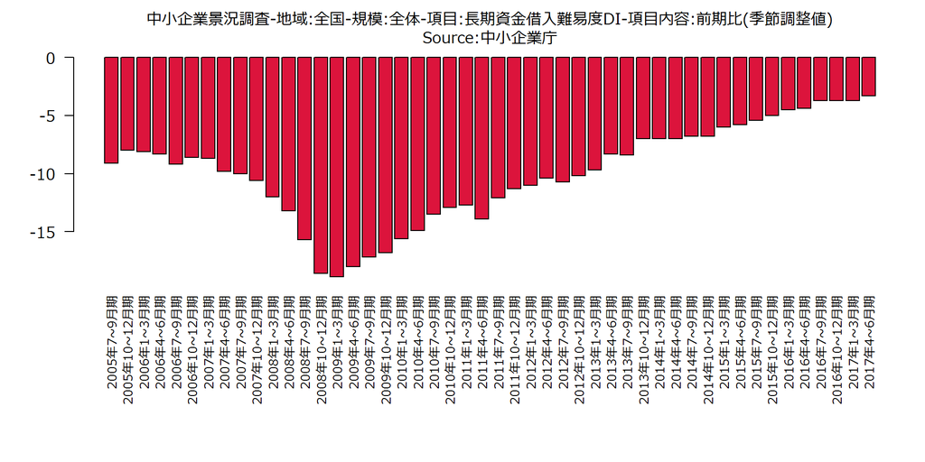

| Item | 2016年4~6月期 | 2016年7~9月期 | 2016年10~12月期 | 2017年1~3月期 | 2017年4~6月期 |
| --- | --- | --- | --- | --- | --- |
| 全産業 | -4.4 | -3.7 | -3.7 | -3.7 | -3.3 |
| 製造業 | -2.1 | -0.8 | -0.6 | -1.2 | -0.7 |
| 非製造業 | -5.1 | -4.8 | -4.9 | -4.7 | -4.2 |
| 建設業 | 0.5 | 2.5 | 1.7 | 1.8 | 2.2 |
| 非製造業(除く建設) | -6.4 | -6.3 | -6.2 | -6.1 | -5.5 |
| 卸売業 | -1 | -1.7 | 0.2 | 0.9 | 3 |
| 小売業 | -9.4 | -9.6 | -9.9 | -9.3 | -9 |
| サービス業 | -5.4 | -4.7 | -4.9 | -4.8 | -4.8 |

#### 中小企業景況調査-地域:全国-規模:全体-項目:短期資金借入難易度-項目内容:前期比(原数値)

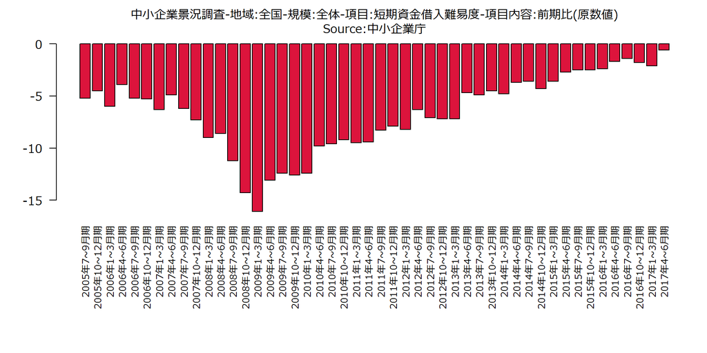

| Item | 2016年4~6月期 | 2016年7~9月期 | 2016年10~12月期 | 2017年1~3月期 | 2017年4~6月期 |
| --- | --- | --- | --- | --- | --- |
| 全産業:好転 | 7.4 | 7.5 | 7 | 6.8 | 7.5 |
| 全産業:不変 | 83.5 | 83.6 | 84.2 | 84.3 | 84.4 |
| 全産業:悪化 | 9.1 | 8.9 | 8.8 | 8.9 | 8.1 |
| 全産業:DI | -1.7 | -1.4 | -1.8 | -2.1 | -0.6 |
| 全産業:製造業:好転 | 8.5 | 8.4 | 7.7 | 7.8 | 8.1 |
| 全産業:製造業:不変 | 85 | 85.3 | 86 | 86 | 86.2 |
| 全産業:製造業:悪化 | 6.5 | 6.3 | 6.3 | 6.2 | 5.7 |
| 全産業:製造業:DI | 2 | 2.1 | 1.4 | 1.6 | 2.4 |
| 全産業:非製造業:好転 | 7 | 7.1 | 6.7 | 6.5 | 7.3 |
| 全産業:非製造業:不変 | 83 | 83 | 83.6 | 83.7 | 83.8 |
| 全産業:非製造業:悪化 | 10 | 9.9 | 9.7 | 9.8 | 8.9 |
| 全産業:非製造業:DI | -3 | -2.8 | -3 | -3.3 | -1.6 |
| 全産業:非製造業:建設業:好転 | 9.4 | 9.9 | 9.4 | 8.7 | 9.9 |
| 全産業:非製造業:建設業:不変 | 85 | 84.6 | 85.4 | 86.2 | 85.6 |
| 全産業:非製造業:建設業:悪化 | 5.6 | 5.5 | 5.2 | 5.1 | 4.5 |
| 全産業:非製造業:建設業:DI | 3.8 | 4.4 | 4.2 | 3.6 | 5.4 |
| 全産業:非製造業:非製造業(除く建設業):好転 | 6.5 | 6.5 | 6.1 | 6 | 6.7 |
| 全産業:非製造業:非製造業(除く建設業):不変 | 82.5 | 82.6 | 83.2 | 83.2 | 83.4 |
| 全産業:非製造業:非製造業(除く建設業):悪化 | 11 | 10.9 | 10.7 | 10.8 | 9.9 |
| 全産業:非製造業:非製造業(除く建設業):DI | -4.5 | -4.4 | -4.6 | -4.8 | -3.2 |
| 全産業:非製造業:非製造業(除く建設業):卸売業:好転 | 8.5 | 7.5 | 8.2 | 9.9 | 10 |
| 全産業:非製造業:非製造業(除く建設業):卸売業:不変 | 84 | 84.9 | 84.3 | 84.1 | 84.7 |
| 全産業:非製造業:非製造業(除く建設業):卸売業:悪化 | 7.5 | 7.6 | 7.5 | 6 | 5.3 |
| 全産業:非製造業:非製造業(除く建設業):卸売業:DI | 1 | -0.1 | 0.7 | 3.9 | 4.7 |
| 全産業:非製造業:非製造業(除く建設業):小売業:好転 | 5.3 | 5.1 | 4.8 | 4.3 | 5.6 |
| 全産業:非製造業:非製造業(除く建設業):小売業:不変 | 82.4 | 82.6 | 82.9 | 83.7 | 83.1 |
| 全産業:非製造業:非製造業(除く建設業):小売業:悪化 | 12.3 | 12.3 | 12.3 | 12 | 11.3 |
| 全産業:非製造業:非製造業(除く建設業):小売業:DI | -7 | -7.2 | -7.5 | -7.7 | -5.7 |
| 全産業:非製造業:非製造業(除く建設業):サービス業:好転 | 7 | 7.4 | 6.7 | 6.4 | 6.9 |
| 全産業:非製造業:非製造業(除く建設業):サービス業:不変 | 82.3 | 82.1 | 83 | 82.6 | 83.2 |
| 全産業:非製造業:非製造業(除く建設業):サービス業:悪化 | 10.7 | 10.5 | 10.3 | 11 | 9.9 |
| 全産業:非製造業:非製造業(除く建設業):サービス業:DI | -3.7 | -3.1 | -3.6 | -4.6 | -3 |

#### 中小企業景況調査-地域:全国-規模:全体-項目:短期資金借入難易度DI-項目内容:前期比(季節調整値)

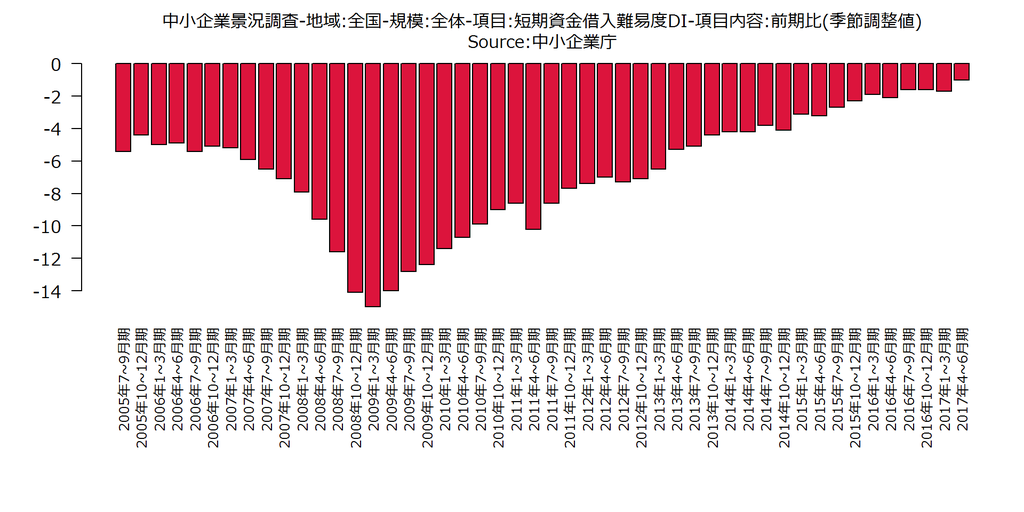

| Item | 2016年4~6月期 | 2016年7~9月期 | 2016年10~12月期 | 2017年1~3月期 | 2017年4~6月期 |
| --- | --- | --- | --- | --- | --- |
| 全産業 | -2.1 | -1.6 | -1.6 | -1.7 | -1 |
| 製造業 | 1.4 | 2 | 2 | 1.6 | 1.8 |
| 非製造業 | -3.4 | -3.1 | -2.9 | -2.7 | -2 |
| 建設業 | 3.8 | 4.1 | 4.2 | 3.8 | 5.4 |
| 非製造業(除く建設) | -5 | -4.6 | -4.4 | -4.2 | -3.7 |
| 卸売業 | 1.3 | -0.7 | 1.4 | 3.4 | 4.9 |
| 小売業 | -7.6 | -7.5 | -7.4 | -6.9 | -6.3 |
| サービス業 | -4.3 | -3.3 | -3.5 | -3.9 | -3.6 |